# report.Rmd

Brian Luu

1/31/2017

## Metric Definition

The three metrics I have chosen to compare the segregation in the cities are the **dissimilarity index**, the **Gini coefficient**, and the **interaction index**.

The **dissimilarity index** ranges from 0.0 to 1.0 (with 0.0 meaning complete integration and 1.0 meaning complete segregation) and measures the ‘percentage of a group’s population that would have to change residence for each neighborhood to have the same percentage of that group as the metropolitan area overall.’ The index is a measure of evenness, and in the equation you can see that it compares each census tract’s minority population against the whole city’s minority population.

The **dissimilarity index** is calculated by the following formula:

$$\sum_{i=1}^n\frac{[t_i|(p_i-P)|]}{[2TP(1-P)]}$$

where the variables are defined below:  
$\sf{t_{i}}$ = total population of i  
P = ratio of X to T (proportion of the metropolitan area’s population that is minority)  
$\sf{p_{i}}$ = ratio of $\sf{x_{i}}$ to $\sf{t_{i}}$ (proportion of area i’s population that is minority)  
T = sum of all $\sf{t_{i}}$ (total population)  
X = sum of all $\sf{x_{i}}$ (total minority population)

The **Gini coefficient** ranges from 0.0 to 1.0 (with 0.0 meaning complete integration and 1.0 meaning complete segregation) and measures the ‘mean absolute difference between all minority proportions weighted across all areal units.’ In the equation, every single areal unit is compared against every other areal unit to give a maximum weighted mean difference. The **Gini** coefficient is also a measure of evenness.

The **Gini coefficient** is calculated by the following formula:

$$\frac{\sum_{i=1}^n \sum_{j=1}^n t_it_j|(p_i-p_j)|}{2T^2P(1-P)}$$
where the variables are defined below: $\sf{t_{i}}$ = total population of i
$\sf{t_{j}}$ = total population of j $\sf{p_{i}}$ = ratio of $\sf{x_{i}}$ to $\sf{t_{i}}$ (proportion of area i’s population that is minority)
$\sf{p_{j}}$ = ratio of $\sf{x_{j}}$ to $\sf{t_{j}}$ (proportion of area j’s population that is minority)
T = sum of all $\sf{t_{i}}$ (total population)
P = ratio of X to T (proportion of the metropolitan area’s population that is minority)

The **interaction index** ranges from 0.0 to 1.0 (the lower the value, the higher the segregation and vice versa) measures the ‘exposure of minority group members to members of the majority group as the minority-weighted average of the majority proportion of the population in each areal unit.’ In the interaction index formula, the equation takes into account each tract’s minority population proportion, as well as each tract’s majority population proportion. The interaction index is different from the above two formulas as it instead is a measure of exposure instead of a measure of evenness.

The **interaction index** is calculated by the following formula:

$$\sum_{i=1}^n[(\frac{x_i}{X})(\frac{y_i}{t_i})]$$
where the variables are defined below: $\sf{x_{i}}$ = the minority population of area i
X = sum of all $\sf{x_{i}}$ (total minority population)
$\sf{y_{i}}$ = the majority population of area i
$\sf{t_{i}}$ = total population of i

## Metric Comparison

Given a small data set containing census tracts of 14 cities, I used the above formulas to calculate their **dissimilarity**, **Gini**, and **interaction** coefficients. The final results are displayed below.

```
##          city dissimilarity      gini interaction my.metric
## 1   baltimore     0.6111194 0.7714606   0.2170937 0.6117491
## 2  charleston     0.4161646 0.5654562   0.5181057 0.3277545
## 3     chicago     0.5173891 0.6957629   0.3362153 0.4591945
## 4    columbus     0.4292138 0.5764418   0.5370268 0.2853474
## 5      dayton     0.5212164 0.6836641   0.5072700 0.1977738
## 6      denver     0.3562831 0.4783317   0.6852802 0.2107780
## 7          kc     0.4498272 0.6029981   0.5806695 0.2057428
## 8     memphis     0.5716063 0.7398043   0.4811954 0.2085507
## 9   milwaukee     0.6187397 0.7599514   0.4042414 0.2652331
## 10    ok_city     0.3217329 0.4361873   0.6134721 0.2829450
## 11 pittsburgh     0.5228730 0.6754723   0.6029657 0.1455801
## 12   st_louis     0.6044759 0.7606564   0.4204528 0.2406595
## 13   syracuse     0.5381421 0.6791990   0.6061708 0.1380149
## 14    wichita     0.4122590 0.5487359   0.6395624 0.2114579
```

### A Closer Look

Let’s take a closer look at each metric. Starting with the dissimilarity indices:

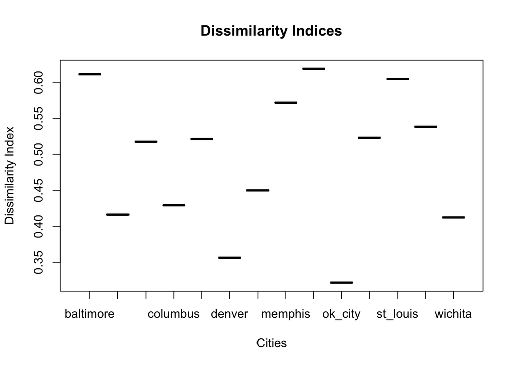

```
##          city dissimilarity
## 1     ok_city     0.3217329
## 2      denver     0.3562831
## 3     wichita     0.4122590
## 4  charleston     0.4161646
## 5    columbus     0.4292138
## 6          kc     0.4498272
## 7     chicago     0.5173891
## 8      dayton     0.5212164
## 9  pittsburgh     0.5228730
## 10   syracuse     0.5381421
## 11    memphis     0.5716063
## 12   st_louis     0.6044759
## 13  baltimore     0.6111194
## 14  milwaukee     0.6187397
```

If we remember, a value of 0.0 means complete integration while a value of 1.0 means complete segregation. Right off the bat, we can see immediately that there are not any extreme outliers. All of the data fits within a range of (0.3217329, 0.6187397), with **Oklahoma City** being the city of most integrated, while **Milwaukee** takes the title of most segregated.

Next, we have the Gini coefficient graph:

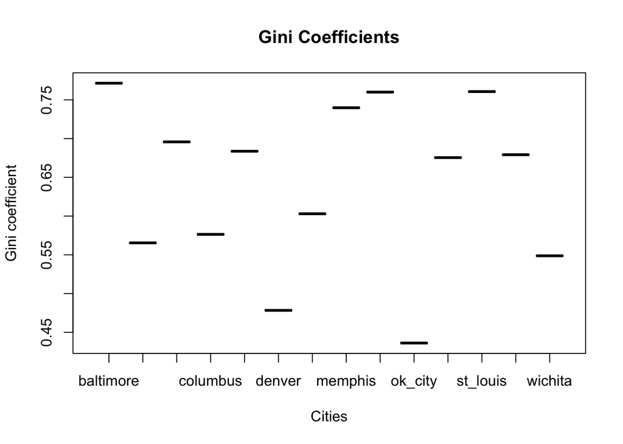

```
##          city      gini
## 1     ok_city 0.4361873
## 2      denver 0.4783317
## 3     wichita 0.5487359
## 4  charleston 0.5654562
## 5    columbus 0.5764418
## 6          kc 0.6029981
## 7  pittsburgh 0.6754723
## 8    syracuse 0.6791990
## 9      dayton 0.6836641
## 10    chicago 0.6957629
## 11    memphis 0.7398043
## 12  milwaukee 0.7599514
## 13   st_louis 0.7606564
## 14  baltimore 0.7714606
```

We can see that again, **Oklahoma City** also has the lowest Gini coefficient, meaning it is also the best integrated city in our dataset. However, it is actually **Baltimore** that has the highest Gini coefficient, with **St. Louis** coming in 2nd highest and **Milwaukee** taking a close 3rd. But when you compare the Gini graph with the dissimilarity graph, you can notice that nearly all the cities stay relatively the same - which makes sense, given that these two coefficients measure the evenness of the city. The similarities between these two graphs tell us that these two different formulas are consistent in their results.

Finally, we have the interaction graph:

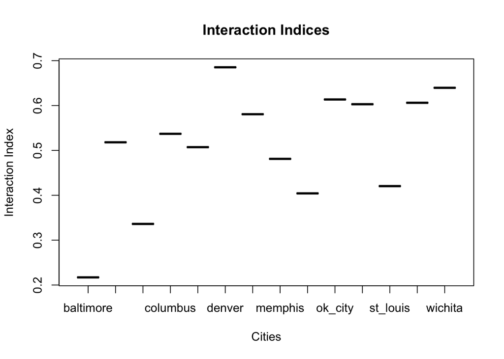

```
##          city interaction
## 1   baltimore   0.2170937
## 2     chicago   0.3362153
## 3   milwaukee   0.4042414
## 4    st_louis   0.4204528
## 5     memphis   0.4811954
## 6      dayton   0.5072700
## 7  charleston   0.5181057
## 8    columbus   0.5370268
## 9          kc   0.5806695
## 10 pittsburgh   0.6029657
## 11   syracuse   0.6061708
## 12    ok_city   0.6134721
## 13    wichita   0.6395624
## 14     denver   0.6852802
```

Now this graph should definitely look different because a lower value indicates higher levels of segregation while a higher value indicates higher levels of integration, which is the complete opposite of the first two equations. We can see that **Baltimore** again scores the highest in segregation - with a low of 0.2170937 - while we have a newcomer to enter the scoreboard: **Denver** with a high index of 0.6852802. Remember that the interaction index is a measure of exposure - the exposure of a minority group member to members of the majority group.

## Metric Proposal

My metric proposal is a simple equation:

$$\sum_{i=1}^n \frac{x_i}{T}$$
where the variables are defined below:
$\sf{x_{i}}$ = the minority population at area i
T = sum of all $\sf{t_{i}}$ (total population)

The Brian coefficient is very simple: take the summative value of each ratio of minority populations over the total population of the whole metropolitan for each areal unit. It takes into account of only minorities in whole city. It is simple and effective, and values range from 0.0 to 1.0, with a higher number meaning higher amounts of segregation.

Below are the results for the Brian coefficient:

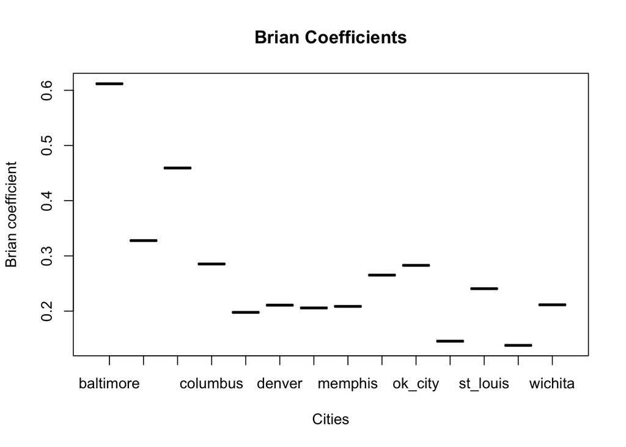

```
##          city my.metric
## 1    syracuse 0.1380149
## 2  pittsburgh 0.1455801
## 3      dayton 0.1977738
## 4          kc 0.2057428
## 5     memphis 0.2085507
## 6      denver 0.2107780
## 7     wichita 0.2114579
## 8    st_louis 0.2406595
## 9   milwaukee 0.2652331
## 10    ok_city 0.2829450
## 11   columbus 0.2853474
## 12 charleston 0.3277545
## 13    chicago 0.4591945
## 14  baltimore 0.6117491
```

As you can see, the coefficient’s results are not very similar to the other metrics. It is very poor and does not actually give a good measure of segregation. I would strongly advise not to use this formula as it is very weak in accurately measuring segregation in a city.